# **Chapter 8 Classification**

## **Introduction**

Classification is one of the most fundamental tasks in **machine learning** and **predictive modeling**.  
It is a **supervised learning** approach, meaning that the model is trained on labeled data—datasets in which the target outcome (or “class”) is already known.  
The goal of classification is to **assign a predefined class label** to new, unseen data points based on their features or characteristics.

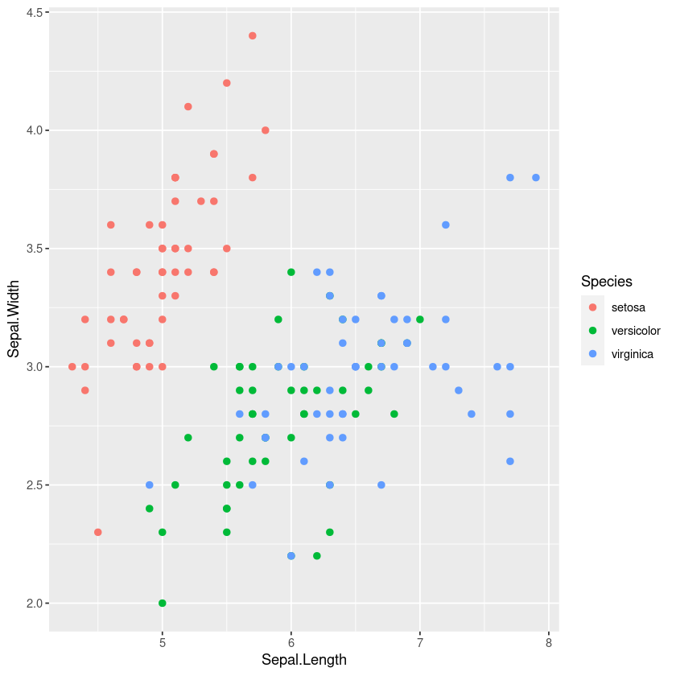

In simpler terms, classification helps a computer learn from examples so that it can correctly categorize new observations into one of several possible groups.

There are two main paradigms for classification:

1. **Model-Based Approach:**  
   Assumes that the data come from an underlying **probabilistic model**—for example, a joint distribution of features and labels.  
   Once this distribution is estimated, we can make predictions by computing the probability that an observation belongs to each class.  
   Examples include:
   - Logistic Regression
   - Linear/Quadratic Discriminant Analysis (LDA/QDA)
   - Naïve Bayes Classifier
2. **Model-Free Approach:**  
   Makes **no assumptions** about the underlying data distribution.  
   Instead, classification rules are determined directly from the training data, often using distance, similarity, or decision boundaries.  
   Examples include:
   - k-Nearest Neighbors (KNN)
   - Decision Trees and Random Forests
   - Support Vector Machines (SVM)

Based on the **number of classes**, classification tasks are categorized as:

- **Binary Classification:**  
  Two possible outcomes, such as  
  “spam” vs. “not spam,”  
  or “disease present” vs. “disease absent.”
- **Multiclass Classification:**  
  More than two possible categories, such as  
  classifying flowers into *setosa*, *versicolor*, and *virginica* in the Iris dataset.
- *(Optional extension)*  
  **Multilabel Classification:**  
  Each observation can belong to **multiple classes simultaneously**, such as tagging an image as both “indoor” and “people.”

**Example Applications**

| **Domain** | **Description** |
| --- | --- |
| **Email Spam Detection** | Email providers such as Gmail classify incoming messages as *spam*, *regular*, or *important* based on content and sender patterns. |
| **Medical Diagnosis** | Identifying whether medical images (e.g., mammograms or retinal scans) indicate the presence of disease. |
| **Sentiment Analysis** | Classifying text (from reviews or social media) into positive, neutral, or negative sentiment. |
| **Credit Scoring** | Assigning applicants to risk categories to evaluate their likelihood of repaying loans. |
| **Image Recognition** | Recognizing handwritten digits (MNIST) or object categories (CIFAR-10). |

## **Metrics to Measure Performance**

Evaluating classification models requires multiple metrics since **no single number** can describe performance in all scenarios.  
The most common metrics are **accuracy**, **precision**, **recall**, and the **Kappa statistic**.

**1. Accuracy**

$$ \text{Accuracy} = \frac{\text{Number of correct predictions}}{\text{Total number of predictions}} $$

Accuracy indicates how often the classifier’s predictions are correct overall.  
However, it can be **misleading for imbalanced datasets**, where one class is much more frequent than others.

> *Example:*  
> If 95% of patients are healthy and 5% have a disease, a model that always predicts “healthy” will have 95% accuracy but 0% recall for the disease class.

**2. Kappa Statistic (Cohen’s Kappa)**

The **Kappa coefficient ($\kappa$)** measures how much better a classifier performs compared to random guessing, taking into account the possibility of agreement by chance.

$$ \kappa = \frac{p_o - p_e}{1 - p_e} $$

where

- $p_o$: observed agreement (accuracy),
- $p_e$: expected agreement by chance.

**Interpretation:**

- $\kappa = 0$: performance equals random guessing
- $\kappa < 0$: worse than random
- $\kappa = 1$: perfect agreement
- $0.61 \le \kappa \le 0.80$: substantial agreement
- $0.81 \le \kappa \le 1.00$: almost perfect agreement

Kappa is especially useful for **imbalanced datasets** and **multi-class problems**, providing a more robust measure than raw accuracy.

**3. Precision (Positive Predictive Value)**

$$ \text{Precision} = \frac{\text{True Positives}}{\text{True Positives} + \text{False Positives}} $$

Precision measures **how often the positive predictions are correct**.  
It is high when false positives are rare.

> *Example:* In spam detection, high precision means that most of the emails flagged as spam are truly spam.

**4. Recall (Sensitivity or True Positive Rate)**

$$ \text{Recall} = \frac{\text{True Positives}}{\text{True Positives} + \text{False Negatives}} $$

Recall measures the model’s **ability to find all actual positives**—how many true positive cases were successfully identified.

> *Example:* In medical diagnosis, high recall means few diseased patients are missed.

**5. F1 Score (Harmonic Mean of Precision and Recall)**

$$ \text{F1} = 2 \times \frac{\text{Precision} \times \text{Recall}}{\text{Precision} + \text{Recall}} $$

The F1 score provides a **balance** between precision and recall and is particularly informative when dealing with **uneven class distributions**.

**Choosing the Right Metric**

- Use **accuracy** when all classes are balanced and equally important.
- Use **precision** when false positives are costly (e.g., flagging legitimate emails as spam).
- Use **recall** when false negatives are costly (e.g., missing a disease case).
- Use **F1** or **Kappa** when you need a balanced assessment across multiple dimensions.

**Example: Building a Classifier Using the Iris Dataset using SVM**

In this example, we will build a **Support Vector Machine (SVM)** classifier using the famous **Iris dataset**.  
The goal is to train a model that can classify iris flowers into one of three species (*setosa*, *versicolor*, or *virginica*), based on their sepal and petal measurements.

```r
library(caret)
library(tidyverse)
#Iris dataset
data(iris)
head(iris)
```

A data.frame: 6 × 5

|  | Sepal.Length <dbl> | Sepal.Width <dbl> | Petal.Length <dbl> | Petal.Width <dbl> | Species <fct> |
| --- | --- | --- | --- | --- | --- |
| 1 | 5.1 | 3.5 | 1.4 | 0.2 | setosa |
| 2 | 4.9 | 3.0 | 1.4 | 0.2 | setosa |
| 3 | 4.7 | 3.2 | 1.3 | 0.2 | setosa |
| 4 | 4.6 | 3.1 | 1.5 | 0.2 | setosa |
| 5 | 5.0 | 3.6 | 1.4 | 0.2 | setosa |
| 6 | 5.4 | 3.9 | 1.7 | 0.4 | setosa |

```r
#Split the data into train set and test set
set.seed(252)

index = createDataPartition(iris$Species, p = 0.75, list = FALSE)
train.dat = iris[index,]
test.dat =   iris[-index,]
```

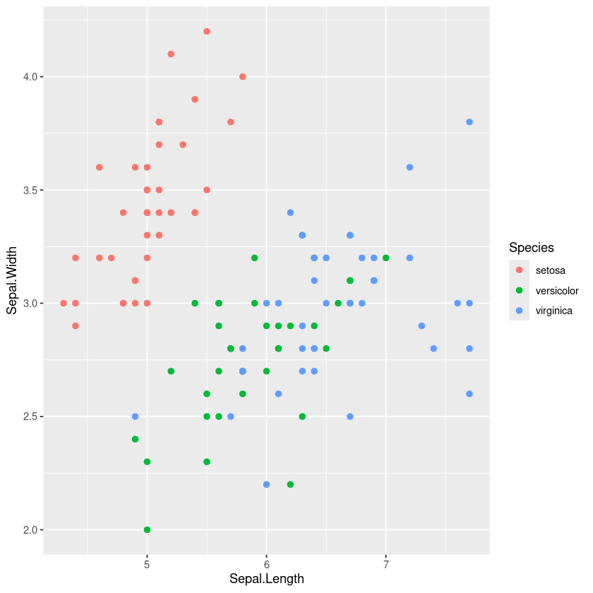

```r
#Basic data visulization
ggplot(data=train.dat, aes(x=Sepal.Length, y=Sepal.Width, color=Species)) + geom_point(size=2)
```

```r
#Build a classfier using the training data

set.seed(295)

#5 folder cross validation
cv.control =  trainControl(method = "cv",
                           number = 5)

#
# create a tuning grid
# hyper parameter:  C   if the method is "svmLinear"
#h_grid <- expand.grid(  C = c(0.25, 0.35, .5, 0.55, 0.6, 0.7))

#train to find the optimal tuning parameters, linear SVM
#SVM.fit0 = train( Species ~ ., data = train.dat,  method = "svmLinear",
#                   trControl = cv.control,
#                   trace = FALSE,
#                   tuneGrid = h_grid,
#                   preProc = c("center", "scale")
#               #    maxit = 500
#                )

# hyper parameter:  C and sigma
hgrid = expand.grid(
    C = c(0.25, .5, 1, 1.5, 2.0, 5.0),
    sigma = c(0.01, 0.05, 0.1, 0.15, 0.2,0.5, 1)
)

#train to find the optimal tuning parameters
SVM.fit0 = train(Species ~ ., data = train.dat,  method = "svmRadial",
                   trControl = cv.control,
                   trace = FALSE,
                   tuneGrid = hgrid,
                   preProc = c("center", "scale")
               #    maxit = 500
                )

#The best tuning paramter
SVM.fit0$bestTune

SVM.fit0
```

A data.frame: 1 × 2

|  | sigma <dbl> | C <dbl> |
| --- | --- | --- |
| 26 | 0.2 | 1.5 |

```
Support Vector Machines with Radial Basis Function Kernel

114 samples
  4 predictor
  3 classes: 'setosa', 'versicolor', 'virginica'

Pre-processing: centered (4), scaled (4)
Resampling: Cross-Validated (5 fold)
Summary of sample sizes: 92, 91, 91, 90, 92
Resampling results across tuning parameters:

  C     sigma  Accuracy   Kappa
  0.25  0.01   0.7592556  0.6431580
  0.25  0.05   0.8659750  0.7983435
  0.25  0.10   0.8655797  0.7977470
  0.25  0.15   0.8837615  0.8250762
  0.25  0.20   0.9102437  0.8647665
  0.25  0.50   0.9204875  0.8805351
  0.25  1.00   0.9197299  0.8793705
  0.50  0.01   0.8576746  0.7867392
  0.50  0.05   0.8746706  0.8114116
  0.50  0.10   0.9375165  0.9059750
  0.50  0.15   0.9375165  0.9061033
  0.50  0.20   0.9204875  0.8805351
  0.50  0.50   0.9291831  0.8935663
  0.50  1.00   0.9375165  0.9061088
  1.00  0.01   0.8568841  0.7846789
  1.00  0.05   0.9466074  0.9197679
  1.00  0.10   0.9204875  0.8805351
  1.00  0.15   0.9382740  0.9072309
  1.00  0.20   0.9382740  0.9072309
  1.00  0.50   0.9466074  0.9197734
  1.00  1.00   0.9288208  0.8930777
  1.50  0.01   0.8746706  0.8114116
  1.50  0.05   0.9291831  0.8936033
  1.50  0.10   0.9382740  0.9072309
  1.50  0.15   0.9466074  0.9197309
  1.50  0.20   0.9556983  0.9334380
  1.50  0.50   0.9379117  0.9067423
  1.50  1.00   0.9288208  0.8930777
  2.00  0.01   0.8746706  0.8114116
  2.00  0.05   0.9375165  0.9060663
  2.00  0.10   0.9556983  0.9333955
  2.00  0.15   0.9466074  0.9197734
  2.00  0.20   0.9556983  0.9334380
  2.00  0.50   0.9379117  0.9067423
  2.00  1.00   0.9288208  0.8930777
  5.00  0.01   0.9379117  0.9066997
  5.00  0.05   0.9466074  0.9197309
  5.00  0.10   0.9466074  0.9197734
  5.00  0.15   0.9466074  0.9197734
  5.00  0.20   0.9466074  0.9197734
  5.00  0.50   0.9295784  0.8942423
  5.00  1.00   0.9204875  0.8805777

Accuracy was used to select the optimal model using the largest value.
The final values used for the model were sigma = 0.2 and C = 1.5.
```

**The Confusion Matrix**

A **confusion matrix** is a table that summarizes the performance of a classification model by showing how well predicted labels match the true labels.

It compares **actual (true)** class values with **predicted** class values and helps identify which types of errors the model makes.

**Confusion Matrix Structure**

For a **binary classification** problem, the confusion matrix is typically represented as:

|  | **Predicted: Positive** | **Predicted: Negative** |
| --- | --- | --- |
| **Actual: Positive** | True Positive (TP) | False Negative (FN) |
| **Actual: Negative** | False Positive (FP) | True Negative (TN) |

- **True Positive (TP):** Model correctly predicts the positive class
- **True Negative (TN):** Model correctly predicts the negative class
- **False Positive (FP):** Model incorrectly predicts positive (Type I error)
- **False Negative (FN):** Model incorrectly predicts negative (Type II error)

If we have $K$ classes (e.g., Class 1, Class 2, Class 3), the confusion matrix looks like this:

| **Actual \ Predicted** | **Class 1** | **Class 2** | **Class 3** |
| --- | --- | --- | --- |
| **Class 1** | $TP_1$ | $FP_{1,2}$ | $FP_{1,3}$ |
| **Class 2** | $FP_{2,1}$ | $TP_2$ | $FP_{2,3}$ |
| **Class 3** | $FP_{3,1}$ | $FP_{3,2}$ | $TP_3$ |

- Each **row** represents the **actual class**,
- Each **column** represents the **predicted class**.
- The diagonal entries ($TP_1, TP_2, TP_3, \ldots$) are correct predictions for each class.
- Off-diagonal entries show **misclassifications** — how often one class is confused with another.

```r
#Make prediction for classfication on the test data
#make prediction of classes
p.class = predict(SVM.fit0, newdata =test.dat)

#The predicted class based on the features
p.class

#cbind(p.class, test.dat$Species)
```

1. setosa

2. setosa

3. setosa

4. setosa

5. setosa

6. setosa

7. setosa

8. setosa

9. setosa

10. setosa

11. setosa

12. setosa

13. versicolor

14. versicolor

15. versicolor

16. versicolor

17. versicolor

18. versicolor

19. versicolor

20. versicolor

21. versicolor

22. versicolor

23. versicolor

24. versicolor

25. virginica

26. virginica

27. virginica

28. virginica

29. virginica

30. virginica

31. virginica

32. virginica

33. virginica

34. virginica

35. virginica

36. virginica

**Levels**:**

1. 'setosa'

2. 'versicolor'

3. 'virginica'

```r
#Make prediction of prob , if it is a binary classfication
#predict(SVM.fit0, newdata = test.dat, type = "prob")

#Confusion matrix
confusionMatrix(p.class, reference = test.dat$Species)
# Accuracy  = 1 (perfect classfication)
```

```
Confusion Matrix and Statistics

            Reference
Prediction   setosa versicolor virginica
  setosa         12          0         0
  versicolor      0         12         0
  virginica       0          0        12

Overall Statistics

               Accuracy : 1
                 95% CI : (0.9026, 1)
    No Information Rate : 0.3333
    P-Value [Acc > NIR] : < 2.2e-16

                  Kappa : 1

 Mcnemar's Test P-Value : NA

Statistics by Class:

                     Class: setosa Class: versicolor Class: virginica
Sensitivity                 1.0000            1.0000           1.0000
Specificity                 1.0000            1.0000           1.0000
Pos Pred Value              1.0000            1.0000           1.0000
Neg Pred Value              1.0000            1.0000           1.0000
Prevalence                  0.3333            0.3333           0.3333
Detection Rate              0.3333            0.3333           0.3333
Detection Prevalence        0.3333            0.3333           0.3333
Balanced Accuracy           1.0000            1.0000           1.0000
```

```r
set.seed(232)
#train to find the optimal tuning parameters, polynomial SVM
SVM.fit2 = train( Species ~ ., data = train.dat,  method = "svmPoly",
                   trControl = cv.control,
                   trace = FALSE,
                   tuneLength = 8,
                   preProc = c("center", "scale")
               #    maxit = 500
                )
#SVM.fit2


#The best tuning paramter
SVM.fit2$bestTune

# hyper parameter:  C   if the method is "svmLinear"
h_grid <- expand.grid( degree=1:5, scale=c(0.05,0.1,0.2, 0.3), C = c(0.25, .5,  0.7, 1.0))

SVM.fit3 = train( Species ~ ., data = train.dat,  method = "svmPoly",
                   trControl = cv.control,
                   trace = FALSE,
                   tuneGrid = h_grid,
                   preProc = c("center", "scale")
               #    maxit = 500
                )
#The best tuning paramter
SVM.fit3$bestTune
```

A data.frame: 1 × 3

|  | degree <int> | scale <dbl> | C <dbl> |
| --- | --- | --- | --- |
| 19 | 1 | 0.1 | 1 |

A data.frame: 1 × 3

|  | degree <int> | scale <dbl> | C <dbl> |
| --- | --- | --- | --- |
| 61 | 4 | 0.3 | 0.25 |

```r
#Make prediction for classfication on the test data
#make prediction of classes
p.class = predict(SVM.fit3, newdata =test.dat)

#The predicted class based on the features
p.class

#Make prediction of prob , if it is a binary classfication
#predict(SVM.fit0, newdata = test.dat, type = "prob")

#Confusion matrix
confusionMatrix(p.class, reference = test.dat$Species)
# Accuracy  = 1 (perfect classfication)
```

1. setosa

2. setosa

3. setosa

4. setosa

5. setosa

6. setosa

7. setosa

8. setosa

9. setosa

10. setosa

11. setosa

12. setosa

13. versicolor

14. versicolor

15. versicolor

16. versicolor

17. versicolor

18. versicolor

19. versicolor

20. versicolor

21. versicolor

22. versicolor

23. versicolor

24. versicolor

25. virginica

26. virginica

27. virginica

28. virginica

29. virginica

30. virginica

31. virginica

32. virginica

33. virginica

34. virginica

35. virginica

36. virginica

**Levels**:**

1. 'setosa'

2. 'versicolor'

3. 'virginica'

```
Confusion Matrix and Statistics

            Reference
Prediction   setosa versicolor virginica
  setosa         12          0         0
  versicolor      0         12         0
  virginica       0          0        12

Overall Statistics

               Accuracy : 1
                 95% CI : (0.9026, 1)
    No Information Rate : 0.3333
    P-Value [Acc > NIR] : < 2.2e-16

                  Kappa : 1

 Mcnemar's Test P-Value : NA

Statistics by Class:

                     Class: setosa Class: versicolor Class: virginica
Sensitivity                 1.0000            1.0000           1.0000
Specificity                 1.0000            1.0000           1.0000
Pos Pred Value              1.0000            1.0000           1.0000
Neg Pred Value              1.0000            1.0000           1.0000
Prevalence                  0.3333            0.3333           0.3333
Detection Rate              0.3333            0.3333           0.3333
Detection Prevalence        0.3333            0.3333           0.3333
Balanced Accuracy           1.0000            1.0000           1.0000
```

```r
#Make prediction for classfication on the test data
#make prediction of classes
p.class = predict(SVM.fit2, newdata =test.dat)

#The predicted class based on the features
p.class

#Make prediction of prob , if it is a binary classfication
#predict(SVM.fit0, newdata = test.dat, type = "prob")

#Confusion matrix
confusionMatrix(p.class, reference = test.dat$Species)
# Accuracy  = 1 (perfect classfication)
```

1. setosa

2. setosa

3. setosa

4. setosa

5. setosa

6. setosa

7. setosa

8. setosa

9. setosa

10. setosa

11. setosa

12. setosa

13. versicolor

14. versicolor

15. versicolor

16. versicolor

17. versicolor

18. versicolor

19. versicolor

20. versicolor

21. versicolor

22. versicolor

23. versicolor

24. versicolor

25. virginica

26. virginica

27. virginica

28. virginica

29. virginica

30. virginica

31. virginica

32. virginica

33. virginica

34. virginica

35. virginica

36. virginica

**Levels**:**

1. 'setosa'

2. 'versicolor'

3. 'virginica'

```
Confusion Matrix and Statistics

            Reference
Prediction   setosa versicolor virginica
  setosa         12          0         0
  versicolor      0         12         0
  virginica       0          0        12

Overall Statistics

               Accuracy : 1
                 95% CI : (0.9026, 1)
    No Information Rate : 0.3333
    P-Value [Acc > NIR] : < 2.2e-16

                  Kappa : 1

 Mcnemar's Test P-Value : NA

Statistics by Class:

                     Class: setosa Class: versicolor Class: virginica
Sensitivity                 1.0000            1.0000           1.0000
Specificity                 1.0000            1.0000           1.0000
Pos Pred Value              1.0000            1.0000           1.0000
Neg Pred Value              1.0000            1.0000           1.0000
Prevalence                  0.3333            0.3333           0.3333
Detection Rate              0.3333            0.3333           0.3333
Detection Prevalence        0.3333            0.3333           0.3333
Balanced Accuracy           1.0000            1.0000           1.0000
```

- The SVM model achieved **perfect classification performance (100% accuracy and κ = 1)** on the test data.
- Every observation was correctly assigned to its species — *setosa*, *versicolor*, or *virginica*.
- **Precision, Recall, Specificity, and F1-scores** are all equal to 1.0, indicating **no false positives or false negatives**.
- Such results are rare in practice but common on the **Iris dataset**, as it is relatively clean and linearly separable in the feature space (especially between *setosa* and the other two classes).
- The SVM algorithm successfully found an optimal decision boundary that perfectly separates all species.

Although perfect performance is impressive, it’s important to remember:

- The **Iris dataset** is small and well-behaved; perfect accuracy here does **not guarantee generalization** to more complex or noisy real-world data.
- For more realistic tasks, cross-validation, tuning, and testing on larger, independent datasets are essential to validate model robustness.

Example: In 'mlbench' package, there is 'Sonar' data. The goal is to classify sonar signals as either rock (R) or mine (M) based on energy patterns returned by sonar pulses.

# Source: UCI Machine Learning Repository.

Please build a predictive model using SVM.

```r
library(mlbench)   # Sonar dataset

data(Sonar)
#head(Sonar)
str(Sonar)

#Response: Class
#V1- V60: Predictors
```

```
'data.frame':	208 obs. of  61 variables:
 $ V1   : num  0.02 0.0453 0.0262 0.01 0.0762 0.0286 0.0317 0.0519 0.0223 0.0164 ...
 $ V2   : num  0.0371 0.0523 0.0582 0.0171 0.0666 0.0453 0.0956 0.0548 0.0375 0.0173 ...
 $ V3   : num  0.0428 0.0843 0.1099 0.0623 0.0481 ...
 $ V4   : num  0.0207 0.0689 0.1083 0.0205 0.0394 ...
 $ V5   : num  0.0954 0.1183 0.0974 0.0205 0.059 ...
 $ V6   : num  0.0986 0.2583 0.228 0.0368 0.0649 ...
 $ V7   : num  0.154 0.216 0.243 0.11 0.121 ...
 $ V8   : num  0.16 0.348 0.377 0.128 0.247 ...
 $ V9   : num  0.3109 0.3337 0.5598 0.0598 0.3564 ...
 $ V10  : num  0.211 0.287 0.619 0.126 0.446 ...
 $ V11  : num  0.1609 0.4918 0.6333 0.0881 0.4152 ...
 $ V12  : num  0.158 0.655 0.706 0.199 0.395 ...
 $ V13  : num  0.2238 0.6919 0.5544 0.0184 0.4256 ...
 $ V14  : num  0.0645 0.7797 0.532 0.2261 0.4135 ...
```

[output cut: 47 more lines]

```r
#Split the data into train set and test set
set.seed(252)

index = createDataPartition(Sonar$Class, p = 0.75, list = FALSE)
train.dat = Sonar[index,]
test.dat =   Sonar[-index,]
```

```r
#
cv.control = trainControl(method = "cv",
                           number = 7)

# hyper parameter:  C   if the method is "svmLinear"
h_grid = expand.grid( degree=1:5, scale=c(0.01, 0.02, 0.03, 0.04, 0.05,0.06, 0.1), C = c(0.15, 0.2, 0.25, .5, 0.6, 0.75))

SVM.fit3 = train( Class ~ ., data = train.dat,  method = "svmPoly",
                   trControl = cv.control,
                   trace = FALSE,
                   tuneGrid = h_grid,
                   preProc = c("center", "scale")
               #    maxit = 500
                )
#The best tuning paramter
SVM.fit3$bestTune
```

A data.frame: 1 × 3

|  | degree <int> | scale <dbl> | C <dbl> |
| --- | --- | --- | --- |
| 94 | 3 | 0.02 | 0.5 |

```r
##Make prediction for classfication on the test data
p.class = predict(SVM.fit3, newdata =test.dat)

#The predicted class based on the features
p.class

#Make prediction of prob , if it is a binary classfication
#predict(SVM.fit0, newdata = test.dat, type = "prob")

#Confusion matrix
confusionMatrix(p.class, reference = test.dat$Class)
# Accuracy  = 1 (perfect classfication)
```

1. R

2. R

3. R

4. M

5. R

6. R

7. R

8. R

9. M

10. M

11. R

12. R

13. M

14. R

15. R

16. R

17. R

18. R

19. R

20. R

21. R

22. R

23. R

24. R

25. M

26. M

27. M

28. M

29. M

30. M

31. M

32. M

33. R

34. M

35. M

36. M

37. M

38. M

39. M

40. M

41. M

42. M

43. M

44. M

45. M

46. M

47. M

48. M

49. M

50. M

51. M

**Levels**:**

1. 'M'

2. 'R'

```
Confusion Matrix and Statistics

          Reference
Prediction  M  R
         M 26  4
         R  1 20

               Accuracy : 0.902
                 95% CI : (0.7859, 0.9674)
    No Information Rate : 0.5294
    P-Value [Acc > NIR] : 1.209e-08

                  Kappa : 0.8019

 Mcnemar's Test P-Value : 0.3711

            Sensitivity : 0.9630
            Specificity : 0.8333
         Pos Pred Value : 0.8667
         Neg Pred Value : 0.9524
             Prevalence : 0.5294
         Detection Rate : 0.5098
   Detection Prevalence : 0.5882
      Balanced Accuracy : 0.8981

       'Positive' Class : M
```

```r
#
cv.control = trainControl(method = "cv",
                           number = 7)

# hyper parameter:  C   if the method is "svmLinear"
h_grid = expand.grid(  C = c(0.15, 0.2, 0.25, .5, 0.6, 0.75))

SVM.fit5 = train( Class ~ ., data = train.dat,  method = "svmLinear",
                   trControl = cv.control,
                   trace = FALSE,
                   tuneGrid = h_grid,
                   preProc = c("center", "scale")
               #    maxit = 500
                )
#The best tuning paramter
SVM.fit5$bestTune


##Make prediction for classfication on the test data
p.class = predict(SVM.fit5, newdata =test.dat)

#The predicted class based on the features
p.class

#Make prediction of prob , if it is a binary classfication
#predict(SVM.fit0, newdata = test.dat, type = "prob")

#Confusion matrix
confusionMatrix(p.class, reference = test.dat$Class)
# Accuracy  = 1 (perfect classfication)
```

A data.frame: 1 × 1

|  | C <dbl> |
| --- | --- |
| 1 | 0.15 |

1. R

2. M

3. R

4. M

5. R

6. R

7. R

8. R

9. M

10. M

11. R

12. R

13. M

14. R

15. R

16. R

17. R

18. M

19. R

20. R

21. R

22. R

23. R

24. R

25. R

26. R

27. R

28. R

29. M

30. M

31. M

32. M

33. M

34. M

35. R

36. M

37. M

38. R

39. M

40. M

41. M

42. M

43. M

44. M

45. M

46. M

47. M

48. M

49. M

50. M

51. M

**Levels**:**

1. 'M'

2. 'R'

```
Confusion Matrix and Statistics

          Reference
Prediction  M  R
         M 21  6
         R  6 18

               Accuracy : 0.7647
                 95% CI : (0.6251, 0.8721)
    No Information Rate : 0.5294
    P-Value [Acc > NIR] : 0.0004667

                  Kappa : 0.5278

 Mcnemar's Test P-Value : 1.0000000

            Sensitivity : 0.7778
            Specificity : 0.7500
         Pos Pred Value : 0.7778
         Neg Pred Value : 0.7500
             Prevalence : 0.5294
         Detection Rate : 0.4118
   Detection Prevalence : 0.5294
      Balanced Accuracy : 0.7639

       'Positive' Class : M
```

```r
# hyper parameter:  C and sigma
h_grid <- expand.grid(
    C = c(0.25, .5, 1, 1.5, 2.0),
    sigma = c(0.01, 0.05, 0.1, 0.15, 0.2)
)


SVM.fit6 = train( Class ~ ., data = train.dat,  method = "svmRadial",
                   trControl = cv.control,
                   trace = FALSE,
                   tuneGrid = h_grid,
                   preProc = c("center", "scale")
               #    maxit = 500
                )
#The best tuning paramter
SVM.fit6$bestTune


##Make prediction for classfication on the test data
p.class = predict(SVM.fit6, newdata =test.dat)

#The predicted class based on the features
p.class

#Make prediction of prob , if it is a binary classfication
#predict(SVM.fit0, newdata = test.dat, type = "prob")

#Confusion matrix
confusionMatrix(p.class, reference = test.dat$Class)
# Accuracy  = 1 (perfect classfication)
```

A data.frame: 1 × 2

|  | sigma <dbl> | C <dbl> |
| --- | --- | --- |
| 17 | 0.05 | 1.5 |

1. M

2. M

3. M

4. M

5. R

6. M

7. R

8. R

9. M

10. M

11. R

12. M

13. M

14. R

15. R

16. R

17. R

18. R

19. M

20. R

21. R

22. M

23. R

24. R

25. M

26. M

27. M

28. M

29. M

30. M

31. M

32. M

33. M

34. M

35. M

36. R

37. R

38. M

39. M

40. M

41. M

42. M

43. M

44. M

45. M

46. M

47. M

48. M

49. M

50. M

51. M

**Levels**:**

1. 'M'

2. 'R'

```
Confusion Matrix and Statistics

          Reference
Prediction  M  R
         M 25 11
         R  2 13

               Accuracy : 0.7451
                 95% CI : (0.6037, 0.8567)
    No Information Rate : 0.5294
    P-Value [Acc > NIR] : 0.001311

                  Kappa : 0.4775

 Mcnemar's Test P-Value : 0.026500

            Sensitivity : 0.9259
            Specificity : 0.5417
         Pos Pred Value : 0.6944
         Neg Pred Value : 0.8667
             Prevalence : 0.5294
         Detection Rate : 0.4902
   Detection Prevalence : 0.7059
      Balanced Accuracy : 0.7338

       'Positive' Class : M
```

```r
# Define training control
ctrl = trainControl(method = "cv", number = 5)

# Fit KNN regression
knn.fit = train(Class ~ .,
                data = train.dat,
                method = "knn",
                trControl = ctrl,
                preProcess = c("center", "scale"),
                tuneLength = 10)

# Model summary
knn.fit

# Predict on test data
pred = predict(knn.fit, newdata = test.dat)

#postResample() is a utility function in the caret package that computes summary statistics comparing predicted values with observed (true) values for regression models.

postResample(pred, test.dat$Class)

confusionMatrix(pred, reference = test.dat$Class)
```

```
k-Nearest Neighbors

157 samples
 60 predictor
  2 classes: 'M', 'R'

Pre-processing: centered (60), scaled (60)
Resampling: Cross-Validated (5 fold)
Summary of sample sizes: 126, 125, 126, 126, 125
Resampling results across tuning parameters:

  k   Accuracy   Kappa
   5  0.8334677  0.6626710
   7  0.7828629  0.5558522
   9  0.7508065  0.4897462
  11  0.7066532  0.4019245
  13  0.7010081  0.3891705
  15  0.6814516  0.3484390
  17  0.7006048  0.3893634
  19  0.7199597  0.4304360
  21  0.7072581  0.4030060
  23  0.7133065  0.4167819

Accuracy was used to select the optimal model using the largest value.
The final value used for the model was k = 5.
```

**Accuracy**

0.803921568627451

**Kappa**

0.60093896713615

```
Confusion Matrix and Statistics

          Reference
Prediction  M  R
         M 25  8
         R  2 16

               Accuracy : 0.8039
                 95% CI : (0.6688, 0.9018)
    No Information Rate : 0.5294
    P-Value [Acc > NIR] : 4.341e-05

                  Kappa : 0.6009

 Mcnemar's Test P-Value : 0.1138

            Sensitivity : 0.9259
            Specificity : 0.6667
         Pos Pred Value : 0.7576
         Neg Pred Value : 0.8889
             Prevalence : 0.5294
         Detection Rate : 0.4902
   Detection Prevalence : 0.6471
      Balanced Accuracy : 0.7963

       'Positive' Class : M
```

```r
library(neuralnet)
```

```r
#Transformed data after min_max scaling
#The class
y= Sonar$Class
Sonar.dat = Sonar[,-61] %>%  mutate_all(scale)
Sonar.dat$Class = y
head(Sonar.dat)
```

A data.frame: 6 × 61

|  | V1 <dbl[,1]> | V2 <dbl[,1]> | V3 <dbl[,1]> | V4 <dbl[,1]> | V5 <dbl[,1]> | V6 <dbl[,1]> | V7 <dbl[,1]> | V8 <dbl[,1]> | V9 <dbl[,1]> | V10 <dbl[,1]> | ⋯ | V52 <dbl[,1]> | V53 <dbl[,1]> | V54 <dbl[,1]> | V55 <dbl[,1]> | V56 <dbl[,1]> | V57 <dbl[,1]> | V58 <dbl[,1]> | V59 <dbl[,1]> | V60 <dbl[,1]> | Class <fct> |
| --- | --- | --- | --- | --- | --- | --- | --- | --- | --- | --- | --- | --- | --- | --- | --- | --- | --- | --- | --- | --- | --- |
| 1 | -0.39858974 | -0.0405504 | -0.02686084 | -0.7133841 | 0.3635789 | -0.10100919 | 0.52038296 | 0.2971264 | 1.1225633 | 0.02113492 | ⋯ | -1.1127473 | -0.5961662 | 0.67925862 | -0.29493423 | 1.4780688 | 1.7595395 | 0.06970211 | 0.1712649 | -0.65736097 | R |
| 2 | 0.70184499 | 0.4206156 | 1.05307772 | 0.3225521 | 0.7758040 | 2.60094185 | 1.51896051 | 2.5049382 | 1.3151517 | 0.58728892 | ⋯ | -0.5210919 | -0.2562391 | -0.84112170 | 0.01546573 | 1.8964708 | 1.0681553 | -0.47126947 | -0.4434843 | -0.41884186 | R |
| 3 | -0.12891799 | 0.5996209 | 1.71925669 | 1.1693547 | 0.3995811 | 2.08829866 | 1.96403155 | 2.8455049 | 3.2249867 | 3.05872598 | ⋯ | 1.0151361 | 0.8343603 | -0.19735706 | 1.22884739 | 2.8204419 | 4.1102457 | 1.30620858 | 0.2521530 | 0.25696230 | R |
| 4 | -0.83354417 | -0.6473478 | 0.48058017 | -0.7176825 | -0.9847033 | -1.14659825 | -0.19334913 | -0.0845432 | -0.9984432 | -0.60899970 | ⋯ | -0.1370349 | -1.0069114 | 0.55598454 | -0.11151607 | -0.1606724 | -0.4874591 | -0.54855113 | -0.6376156 | 1.03214942 | R |
| 5 | 2.04585419 | 0.8544758 | 0.11105902 | -0.3114752 | -0.2916611 | -0.67117669 | -0.01370227 | 1.3141291 | 1.5068954 | 1.76795437 | ⋯ | -1.0712276 | -0.7519661 | -0.06038586 | 0.24121116 | -1.1718106 | -0.1071978 | -0.48672581 | 0.4462843 | 0.57498778 | R |
| 6 | -0.02452892 | 0.2082365 | -0.41980235 | -0.7843091 | -0.6624837 | -0.09424162 | -0.02664980 | 0.5695798 | 0.2744986 | 0.71153034 | ⋯ | -0.9259087 | -1.3185112 | -0.97809290 | -1.12737048 | 0.1182623 | -0.3664669 | -0.81130875 | -0.4596619 | -0.06106319 | R |